# Life Expectancy Prediction

CSC532 Final Project

Joseph Le

How do we determine the life quality of a country? Which issues that a country need to improve to provide a better life quality for people? The project will work on a dataset which is collected from most countries in the world. Base on data analysis for the dataset, we could know which predictors could affect life expectancy of a country. Base on the predictors, a country should know how they could make a better life quality. This is the link to the dataset and its variables’ descriptions:

- [Life Expectancy Dataset](https://www.kaggle.com/kumarajarshi/life-expectancy-who)

```r
life_expectancy <- read.csv("C:/Users/Joe/Desktop/ML/Life Expectancy Data.csv")
str(life_expectancy)
```

```
'data.frame':   2938 obs. of  22 variables:
 $ Country                        : Factor w/ 193 levels "Afghanistan",..: 1 1 1 1 1 1 1 1 1 1 ...
 $ Year                           : int  2015 2014 2013 2012 2011 2010 2009 2008 2007 2006 ...
 $ Status                         : Factor w/ 2 levels "Developed","Developing": 2 2 2 2 2 2 2 2 2 2 ...
 $ Life.expectancy                : num  65 59.9 59.9 59.5 59.2 58.8 58.6 58.1 57.5 57.3 ...
 $ Adult.Mortality                : int  263 271 268 272 275 279 281 287 295 295 ...
 $ infant.deaths                  : int  62 64 66 69 71 74 77 80 82 84 ...
 $ Alcohol                        : num  0.01 0.01 0.01 0.01 0.01 0.01 0.01 0.03 0.02 0.03 ...
 $ percentage.expenditure         : num  71.3 73.5 73.2 78.2 7.1 ...
 $ Hepatitis.B                    : int  65 62 64 67 68 66 63 64 63 64 ...
 $ Measles                        : int  1154 492 430 2787 3013 1989 2861 1599 1141 1990 ...
 $ BMI                            : num  19.1 18.6 18.1 17.6 17.2 16.7 16.2 15.7 15.2 14.7 ...
 $ under.five.deaths              : int  83 86 89 93 97 102 106 110 113 116 ...
 $ Polio                          : int  6 58 62 67 68 66 63 64 63 58 ...
 $ Total.expenditure              : num  8.16 8.18 8.13 8.52 7.87 9.2 9.42 8.33 6.73 7.43 ...
 $ Diphtheria                     : int  65 62 64 67 68 66 63 64 63 58 ...
 $ HIV.AIDS                       : num  0.1 0.1 0.1 0.1 0.1 0.1 0.1 0.1 0.1 0.1 ...
 $ GDP                            : num  584.3 612.7 631.7 670 63.5 ...
 $ Population                     : num  33736494 327582 31731688 3696958 2978599 ...
 $ thinness..1.19.years           : num  17.2 17.5 17.7 17.9 18.2 18.4 18.6 18.8 19 19.2 ...
 $ thinness.5.9.years             : num  17.3 17.5 17.7 18 18.2 18.4 18.7 18.9 19.1 19.3 ...
 $ Income.composition.of.resources: num  0.479 0.476 0.47 0.463 0.454 0.448 0.434 0.433 0.415 0.405 ...
 $ Schooling                      : num  10.1 10 9.9 9.8 9.5 9.2 8.9 8.7 8.4 8.1 ...
```

```r
summary(life_expectancy)
```

```
                Country          Year             Status     Life.expectancy Adult.Mortality infant.deaths       Alcohol        percentage.expenditure
 Afghanistan        :  16   Min.   :2000   Developed : 512   Min.   :36.30   Min.   :  1.0   Min.   :   0.0   Min.   : 0.0100   Min.   :    0.000
 Albania            :  16   1st Qu.:2004   Developing:2426   1st Qu.:63.10   1st Qu.: 74.0   1st Qu.:   0.0   1st Qu.: 0.8775   1st Qu.:    4.685
 Algeria            :  16   Median :2008                     Median :72.10   Median :144.0   Median :   3.0   Median : 3.7550   Median :   64.913
 Angola             :  16   Mean   :2008                     Mean   :69.22   Mean   :164.8   Mean   :  30.3   Mean   : 4.6029   Mean   :  738.251
 Antigua and Barbuda:  16   3rd Qu.:2012                     3rd Qu.:75.70   3rd Qu.:228.0   3rd Qu.:  22.0   3rd Qu.: 7.7025   3rd Qu.:  441.534
 Argentina          :  16   Max.   :2015                     Max.   :89.00   Max.   :723.0   Max.   :1800.0   Max.   :17.8700   Max.   :19479.912
 (Other)            :2842                                    NA's   :10      NA's   :10                       NA's   :194
  Hepatitis.B       Measles              BMI        under.five.deaths     Polio       Total.expenditure   Diphtheria       HIV.AIDS
 Min.   : 1.00   Min.   :     0.0   Min.   : 1.00   Min.   :   0.00   Min.   : 3.00   Min.   : 0.370    Min.   : 2.00   Min.   : 0.100
 1st Qu.:77.00   1st Qu.:     0.0   1st Qu.:19.30   1st Qu.:   0.00   1st Qu.:78.00   1st Qu.: 4.260    1st Qu.:78.00   1st Qu.: 0.100
 Median :92.00   Median :    17.0   Median :43.50   Median :   4.00   Median :93.00   Median : 5.755    Median :93.00   Median : 0.100
 Mean   :80.94   Mean   :  2419.6   Mean   :38.32   Mean   :  42.04   Mean   :82.55   Mean   : 5.938    Mean   :82.32   Mean   : 1.742
 3rd Qu.:97.00   3rd Qu.:   360.2   3rd Qu.:56.20   3rd Qu.:  28.00   3rd Qu.:97.00   3rd Qu.: 7.492    3rd Qu.:97.00   3rd Qu.: 0.800
 Max.   :99.00   Max.   :212183.0   Max.   :87.30   Max.   :2500.00   Max.   :99.00   Max.   :17.600    Max.   :99.00   Max.   :50.600
 NA's   :553                        NA's   :34                        NA's   :19      NA's   :226       NA's   :19
      GDP              Population        thinness..1.19.years thinness.5.9.years Income.composition.of.resources   Schooling
 Min.   :     1.68   Min.   :3.400e+01   Min.   : 0.10        Min.   : 0.10      Min.   :0.0000                  Min.   : 0.00
 1st Qu.:   463.94   1st Qu.:1.958e+05   1st Qu.: 1.60        1st Qu.: 1.50      1st Qu.:0.4930                  1st Qu.:10.10
 Median :  1766.95   Median :1.387e+06   Median : 3.30        Median : 3.30      Median :0.6770                  Median :12.30
 Mean   :  7483.16   Mean   :1.275e+07   Mean   : 4.84        Mean   : 4.87      Mean   :0.6276                  Mean   :11.99
 3rd Qu.:  5910.81   3rd Qu.:7.420e+06   3rd Qu.: 7.20        3rd Qu.: 7.20      3rd Qu.:0.7790                  3rd Qu.:14.30
 Max.   :119172.74   Max.   :1.294e+09   Max.   :27.70        Max.   :28.60      Max.   :0.9480                  Max.   :20.70
 NA's   :448         NA's   :652         NA's   :34           NA's   :34         NA's   :167                     NA's   :163
```

The dataset consists of 22 variables and 2938 observations. There are 2 factors and 20 numeric variables.

## 1. Data Cleaning

There are spaces in the names of variables so they need to be cleaned.

```r
library(janitor)
life_expectancy <- clean_names(life_expectancy)
```

The name of thinness_1_19_years variable should be changed to thinness_10_19_years since its description showed that the ages are from 10 to 19.

```r
names(life_expectancy)[19] <- "thinness_10_19_years"
```

For the dataset, I’d like to know how education, health care and economic systems affect the life expectancy. Thus, Country and Year variables will be dropped since they are specific identifiers and not used in the purpose of predicting the life expectancy.

```r
life_expectancy <- life_expectancy[-c(1,2)]
```

There are some missing values in the outcome variable life_expectancy so they need to be removed.

```r
life_expectancy <-  life_expectancy[!is.na(life_expectancy$life_expectancy),]
str(life_expectancy)
```

```
'data.frame':   2928 obs. of  20 variables:
 $ status                         : Factor w/ 2 levels "Developed","Developing": 2 2 2 2 2 2 2 2 2 2 ...
 $ life_expectancy                : num  65 59.9 59.9 59.5 59.2 58.8 58.6 58.1 57.5 57.3 ...
 $ adult_mortality                : int  263 271 268 272 275 279 281 287 295 295 ...
 $ infant_deaths                  : int  62 64 66 69 71 74 77 80 82 84 ...
 $ alcohol                        : num  0.01 0.01 0.01 0.01 0.01 0.01 0.01 0.03 0.02 0.03 ...
 $ percentage_expenditure         : num  71.3 73.5 73.2 78.2 7.1 ...
 $ hepatitis_b                    : int  65 62 64 67 68 66 63 64 63 64 ...
 $ measles                        : int  1154 492 430 2787 3013 1989 2861 1599 1141 1990 ...
 $ bmi                            : num  19.1 18.6 18.1 17.6 17.2 16.7 16.2 15.7 15.2 14.7 ...
 $ under_five_deaths              : int  83 86 89 93 97 102 106 110 113 116 ...
 $ polio                          : int  6 58 62 67 68 66 63 64 63 58 ...
 $ total_expenditure              : num  8.16 8.18 8.13 8.52 7.87 9.2 9.42 8.33 6.73 7.43 ...
 $ diphtheria                     : int  65 62 64 67 68 66 63 64 63 58 ...
 $ hiv_aids                       : num  0.1 0.1 0.1 0.1 0.1 0.1 0.1 0.1 0.1 0.1 ...
 $ gdp                            : num  584.3 612.7 631.7 670 63.5 ...
 $ population                     : num  33736494 327582 31731688 3696958 2978599 ...
 $ thinness_10_19_years           : num  17.2 17.5 17.7 17.9 18.2 18.4 18.6 18.8 19 19.2 ...
 $ thinness_5_9_years             : num  17.3 17.5 17.7 18 18.2 18.4 18.7 18.9 19.1 19.3 ...
 $ income_composition_of_resources: num  0.479 0.476 0.47 0.463 0.454 0.448 0.434 0.433 0.415 0.405 ...
 $ schooling                      : num  10.1 10 9.9 9.8 9.5 9.2 8.9 8.7 8.4 8.1 ...
```

```r
summary(life_expectancy)
```

```
        status     life_expectancy adult_mortality infant_deaths        alcohol       percentage_expenditure  hepatitis_b       measles
 Developed : 512   Min.   :36.30   Min.   :  1.0   Min.   :   0.00   Min.   : 0.010   Min.   :    0.000      Min.   : 1.00   Min.   :     0.0
 Developing:2416   1st Qu.:63.10   1st Qu.: 74.0   1st Qu.:   0.00   1st Qu.: 0.905   1st Qu.:    4.854      1st Qu.:77.00   1st Qu.:     0.0
                   Median :72.10   Median :144.0   Median :   3.00   Median : 3.770   Median :   65.611      Median :92.00   Median :    17.0
                   Mean   :69.22   Mean   :164.8   Mean   :  30.41   Mean   : 4.615   Mean   :  740.321      Mean   :80.96   Mean   :  2427.9
                   3rd Qu.:75.70   3rd Qu.:228.0   3rd Qu.:  22.00   3rd Qu.: 7.715   3rd Qu.:  442.614      3rd Qu.:97.00   3rd Qu.:   362.2
                   Max.   :89.00   Max.   :723.0   Max.   :1800.00   Max.   :17.870   Max.   :19479.912      Max.   :99.00   Max.   :212183.0
                                                                     NA's   :193                             NA's   :553
      bmi        under_five_deaths     polio       total_expenditure   diphtheria       hiv_aids           gdp              population
 Min.   : 1.00   Min.   :   0.00   Min.   : 3.00   Min.   : 0.37     Min.   : 2.00   Min.   : 0.100   Min.   :     1.68   Min.   :3.400e+01
 1st Qu.:19.30   1st Qu.:   0.00   1st Qu.:78.00   1st Qu.: 4.26     1st Qu.:78.00   1st Qu.: 0.100   1st Qu.:   463.85   1st Qu.:1.967e+05
 Median :43.35   Median :   4.00   Median :93.00   Median : 5.75     Median :93.00   Median : 0.100   Median :  1764.97   Median :1.392e+06
 Mean   :38.24   Mean   :  42.18   Mean   :82.55   Mean   : 5.93     Mean   :82.32   Mean   : 1.748   Mean   :  7494.21   Mean   :1.276e+07
 3rd Qu.:56.10   3rd Qu.:  28.00   3rd Qu.:97.00   3rd Qu.: 7.49     3rd Qu.:97.00   3rd Qu.: 0.800   3rd Qu.:  5932.90   3rd Qu.:7.427e+06
 Max.   :77.60   Max.   :2500.00   Max.   :99.00   Max.   :17.60     Max.   :99.00   Max.   :50.600   Max.   :119172.74   Max.   :1.294e+09
 NA's   :32                        NA's   :19      NA's   :226       NA's   :19                       NA's   :443         NA's   :644
 thinness_10_19_years thinness_5_9_years income_composition_of_resources   schooling
 Min.   : 0.100       Min.   : 0.100     Min.   :0.0000                  Min.   : 0.0
 1st Qu.: 1.600       1st Qu.: 1.575     1st Qu.:0.4930                  1st Qu.:10.1
 Median : 3.300       Median : 3.400     Median :0.6770                  Median :12.3
 Mean   : 4.851       Mean   : 4.881     Mean   :0.6274                  Mean   :12.0
 3rd Qu.: 7.200       3rd Qu.: 7.200     3rd Qu.:0.7792                  3rd Qu.:14.3
 Max.   :27.700       Max.   :28.600     Max.   :0.9480                  Max.   :20.7
 NA's   :32           NA's   :32         NA's   :160                     NA's   :160
```

There are missing values in some variables. Instead of omitting them which will cause loss of informations, Random Forest model will be used to impute data for variables with missing values.

```r
temp <- colMeans(is.na(life_expectancy))
temp[temp != 0]
```

```
                        alcohol                     hepatitis_b                             bmi                           polio
                    0.065915301                     0.188866120                     0.010928962                     0.006489071
              total_expenditure                      diphtheria                             gdp                      population
                    0.077185792                     0.006489071                     0.151297814                     0.219945355
           thinness_10_19_years              thinness_5_9_years income_composition_of_resources                       schooling
                    0.010928962                     0.010928962                     0.054644809                     0.054644809
```

```r
mean(complete.cases(life_expectancy))
```

```
[1] 0.5631831
```

```r
library(missForest)
life_expectancy_imp <- missForest(life_expectancy[,-2])
```

```
  missForest iteration 1 in progress...done!
  missForest iteration 2 in progress...done!
  missForest iteration 3 in progress...done!
```

```r
life_expectancy_imp$ximp
```

|  | status | adult_mortality | infant_deaths | alcohol | percentage_expenditure | hepatitis_b | measles | bmi | under_five_deaths | polio | total_expenditure | diphtheria | hiv_aids | gdp | population | thinness_10_19_years | thinness_5_9_years | income_composition_of_resources | schooling |
| --- | --- | --- | --- | --- | --- | --- | --- | --- | --- | --- | --- | --- | --- | --- | --- | --- | --- | --- | --- |
| 1 | Developing | 263 | 62 | 0.010000 | 7.127962e+01 | 65.00000 | 1154 | 19.1 | 83 | 6 | 8.160000 | 65 | 0.1 | 584.259210 | 33736494.0 | 17.2 | 17.3 | 0.4790000 | 10.10000 |
| 2 | Developing | 271 | 64 | 0.010000 | 7.352358e+01 | 62.00000 | 492 | 18.6 | 86 | 58 | 8.180000 | 62 | 0.1 | 612.696514 | 327582.0 | 17.5 | 17.5 | 0.4760000 | 10.00000 |
| 3 | Developing | 268 | 66 | 0.010000 | 7.321924e+01 | 64.00000 | 430 | 18.1 | 89 | 62 | 8.130000 | 64 | 0.1 | 631.744976 | 31731688.0 | 17.7 | 17.7 | 0.4700000 | 9.90000 |
| 4 | Developing | 272 | 69 | 0.010000 | 7.818422e+01 | 67.00000 | 2787 | 17.6 | 93 | 67 | 8.520000 | 67 | 0.1 | 669.959000 | 3696958.0 | 17.9 | 18.0 | 0.4630000 | 9.80000 |
| 5 | Developing | 275 | 71 | 0.010000 | 7.097109e+00 | 68.00000 | 3013 | 17.2 | 97 | 68 | 7.870000 | 68 | 0.1 | 63.537231 | 2978599.0 | 18.2 | 18.2 | 0.4540000 | 9.50000 |
| 6 | Developing | 279 | 74 | 0.010000 | 7.967937e+01 | 66.00000 | 1989 | 16.7 | 102 | 66 | 9.200000 | 66 | 0.1 | 553.328940 | 2883167.0 | 18.4 | 18.4 | 0.4480000 | 9.20000 |
| 7 | Developing | 281 | 77 | 0.010000 | 5.676222e+01 | 63.00000 | 2861 | 16.2 | 106 | 63 | 9.420000 | 63 | 0.1 | 445.893298 | 284331.0 | 18.6 | 18.7 | 0.4340000 | 8.90000 |
| 8 | Developing | 287 | 80 | 0.030000 | 2.587393e+01 | 64.00000 | 1599 | 15.7 | 110 | 64 | 8.330000 | 64 | 0.1 | 373.361116 | 2729431.0 | 18.8 | 18.9 | 0.4330000 | 8.70000 |
| 9 | Developing | 295 | 82 | 0.020000 | 1.091016e+01 | 63.00000 | 1141 | 15.2 | 113 | 63 | 6.730000 | 63 | 0.1 | 369.835796 | 26616792.0 | 19.0 | 19.1 | 0.4150000 | 8.40000 |
| 10 | Developing | 295 | 84 | 0.030000 | 1.717152e+01 | 64.00000 | 1990 | 14.7 | 116 | 58 | 7.430000 | 58 | 0.1 | 272.563770 | 2589345.0 | 19.2 | 19.3 | 0.4050000 | 8.10000 |

[output cut: 990 more lines]

```r
life_expectancy_imp$OOBerror
```

```
    NRMSE       PFC
0.7662432 0.0000000
```

```r
life_expectancy = life_expectancy$life_expectancy
life_expectancy_imp_app <- cbind(life_expectancy_imp$ximp, life_expectancy)
```

## 2. Data Exploration

The plots and relationships between the life_expectancy variable and other variables are explored here.

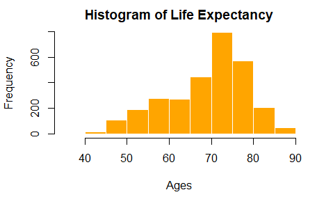

```r
hist(life_expectancy,
     main="Histogram of Life Expectancy",
     xlab="Ages",
     border="white",
     col="orange")
```

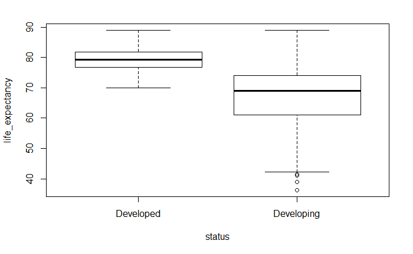

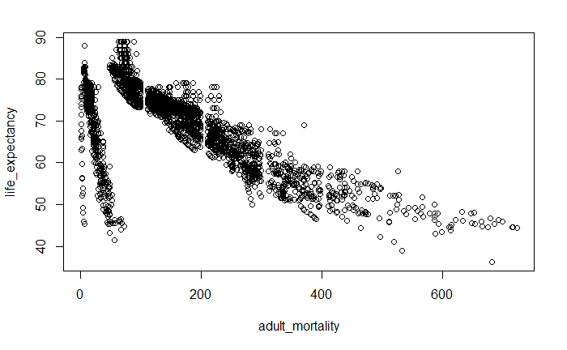

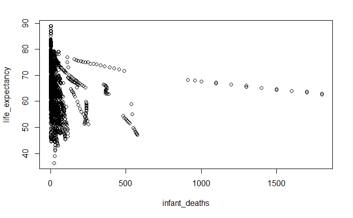

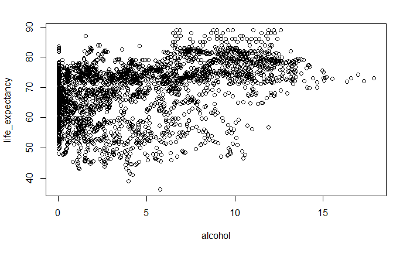

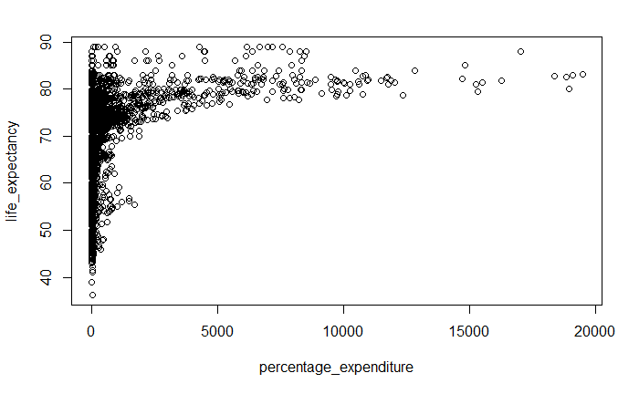

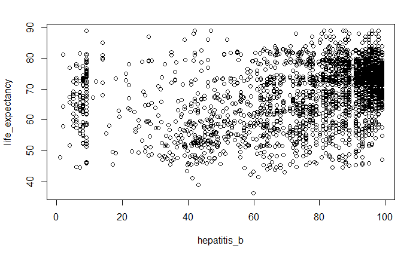

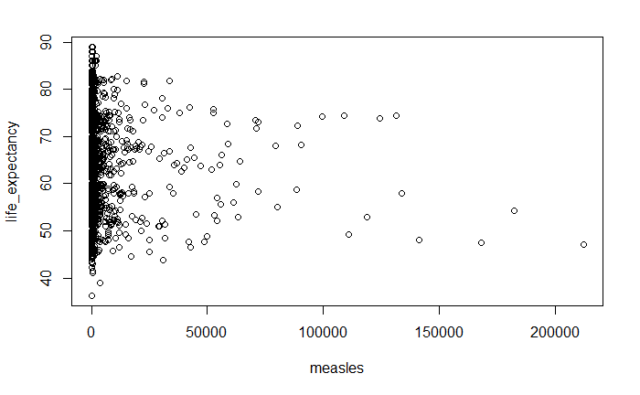

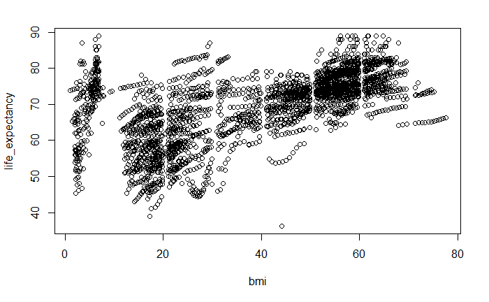

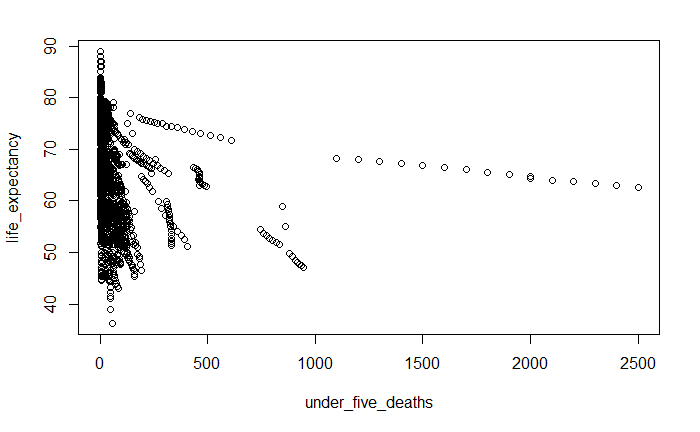

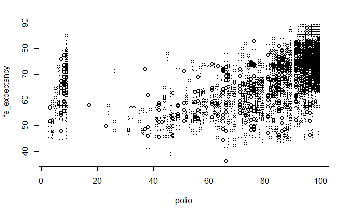

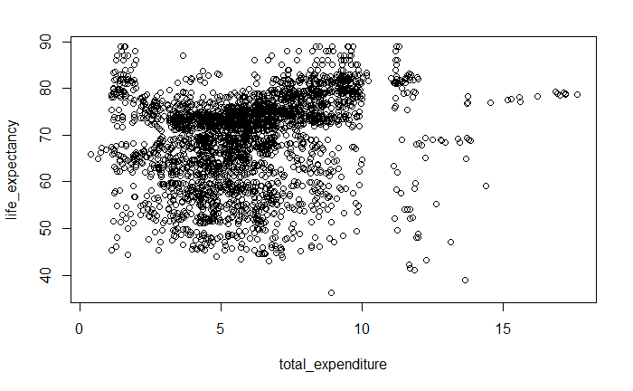

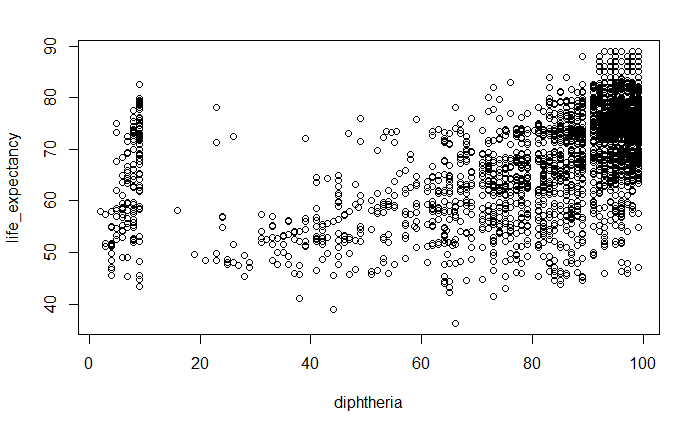

[7 more figures not shown]

```r
plot(life_expectancy ~., data = life_expectancy_imp_app)
```

```r
cor(life_expectancy_imp_app[sapply(life_expectancy_imp_app, function(x) !is.factor(x))], life_expectancy_imp_app$life_expectancy)
```

```
                                       [,1]
adult_mortality                 -0.69635931
infant_deaths                   -0.19655718
alcohol                          0.41149964
percentage_expenditure           0.38186350
hepatitis_b                      0.35846983
measles                         -0.15758580
bmi                              0.57129886
under_five_deaths               -0.22252912
polio                            0.46729740
total_expenditure                0.23039933
diphtheria                       0.48035118
hiv_aids                        -0.55655625
gdp                              0.45318663
population                      -0.02748237
thinness_10_19_years            -0.47982034
thinness_5_9_years              -0.47213749
income_composition_of_resources  0.73152646
schooling                        0.76218873
life_expectancy                  1.00000000
```

```r
t.test(life_expectancy_imp_app$life_expectancy~life_expectancy_imp_app$status, alternative="two.sided")
```

```
    Welch Two Sample t-test

data:  life_expectancy_imp_app$life_expectancy by life_expectancy_imp_app$status
t = 47.868, df = 1807, p-value < 2.2e-16
alternative hypothesis: true difference in means is not equal to 0
95 percent confidence interval:
 11.59118 12.58159
sample estimates:
 mean in group Developed mean in group Developing
                79.19785                 67.11147
```

## 3. Creating Predictive Models

Now we can start to working on machine learning models to predict life expectancy of a country based on the features. There are three categories of models including Regularized Linear Regression, Tree-based Ensemble, and Neural Networks with drop out layers.

#### Creating Regularized Linear Regression Models

These models consist of Lasso, Ridge, and Elastic net. 10 fold cross validation is used for all the models. RMSE of each model is computed and later used for comparisons between machine learning models.

```r
library(caret)
index <- createDataPartition(life_expectancy_imp_app$life_expectancy, p = 0.90, list = FALSE, times=1)
life_expectancy_train <- life_expectancy_imp_app[index,]
life_expectancy_test <- life_expectancy_imp_app[-index,]

set.seed(1)
lasso <- train(
  life_expectancy ~., data = life_expectancy_train, method = "glmnet",
  trControl = trainControl("cv", number = 10),
  tuneGrid = expand.grid(alpha = 1, lambda = 10^seq(-3, 3, length = 100)))
coef(lasso$finalModel, lasso$bestTune$lambda)
predictions <- predict(lasso,life_expectancy_test)
RMSE(predictions, life_expectancy_test$life_expectancy)

set.seed(1)
ridge <- train(
  life_expectancy ~., data = life_expectancy_train, method = "glmnet",
  trControl = trainControl("cv", number = 10),
  tuneGrid = expand.grid(alpha = 0, lambda = 10^seq(-3, 3, length = 100)))
predictions <- predict(ridge,life_expectancy_test)
RMSE(predictions, life_expectancy_test$life_expectancy)

set.seed(1)
enet <- train(
  life_expectancy ~., data = life_expectancy_train, method = "glmnet",
  trControl = trainControl("cv", number = 10),
  tuneGrid = expand.grid(alpha =seq(0,1, length=10), lambda = 10^seq(-3, 3, length = 100)))
predictions <- predict(enet,life_expectancy_test)
RMSE(predictions, life_expectancy_test$life_expectancy)
```

[output not shown]

#### Creating Tree-Ensemble Models

The models consist of Random Forest model and Gradient Boosted Tree model. In the Caret package, “rf” method is used to train a random forest model on the traning data to predict life_expectancy. “gbm” method is used to train Gradient Boosted Tree model. In similar to Regularized Linear Regression Models, 10 fold cross validation is used for all the models. RMSEs are also computed.

```r
set.seed(1)
library(randomForest)
rf <- randomForest(life_expectancy ~ ., data = life_expectancy_train, importance=T)
randomForest(formula=life_expectancy ~ ., data = life_expectancy_train)
```

```
Call:
 randomForest(formula = life_expectancy ~ ., data = life_expectancy_train)
               Type of random forest: regression
                     Number of trees: 500
No. of variables tried at each split: 6

          Mean of squared residuals: 3.122866
                    % Var explained: 96.56
```

```r
ctrl <- trainControl(method = "cv", number = 10)
grid_rf <- expand.grid(mtry = c(4, 8, 16, 20))
set.seed(1)
m_rf <- train(life_expectancy ~ ., data = life_expectancy_train, method = "rf", trControl = ctrl, tuneGrid = grid_rf)
```

[output not shown]

```r
m_rf
```

```
Random Forest

2636 samples
  19 predictor

No pre-processing
Resampling: Cross-Validated (10 fold)
Summary of sample sizes: 2372, 2372, 2371, 2373, 2372, 2374, ...
Resampling results across tuning parameters:

  mtry  RMSE      Rsquared   MAE
   4    1.835479  0.9639043  1.199639
   8    1.766198  0.9660532  1.124680
  16    1.779635  0.9653406  1.126742
  20    1.793275  0.9648140  1.135731

RMSE was used to select the optimal model using the smallest value.
The final value used for the model was mtry = 8.
```

```r
rf_predictions=predict(m_rf, life_expectancy_test)
RMSE(rf_predictions, life_expectancy_test$life_expectancy)
```

```
[1] 2.176333
```

```r
varImp(m_rf)
```

```
rf variable importance
```

|  | Overall |
| --- | --- |
| income_composition_of_resources | 100.0000000 |
| hiv_aids | 85.9999424 |
| adult_mortality | 46.6567809 |
| schooling | 33.5128462 |
| bmi | 9.0696699 |
| under_five_deaths | 4.9617565 |
| thinness_5_9_years | 3.8215916 |
| thinness_10_19_years | 3.2012817 |
| diphtheria | 2.8424282 |
| gdp | 2.7037457 |

[output cut: 9 more lines]

The result of varImp indicated that the top three of features that predict life expectancy of a country could be income, hiv_aids and adult_morality.

```r
set.seed(1)
gbm <- train(life_expectancy ~., data = life_expectancy_train, method = "gbm", preProc="nzv", trControl = trainControl("cv", number = 10))
gbm

gbm_predictions=predict(gbm, life_expectancy_test)
RMSE(gbm_predictions, life_expectancy_test$life_expectancy)
```

[output not shown]

#### Creating a Neural Network Model

Neural Network model with drop out layres is used to predict life expectancy. The model does not accept categorical variables so the variables must be converted to numeric variables. After all processes of analyzing the dataset, there is only one categorical variable left which is status. It has two levels including “Developed” and “Developing” so as.numeric is used to convert the factor variable to numeric variable.

```r
life_expectancy_train$status <- as.numeric(ifelse(life_expectancy_train$status=="Developed", 0, 1))
life_expectancy_test$status <- as.numeric(ifelse(life_expectancy_test$status=="Developed", 0, 1))
```

The traning data is divided into two portions: a training set with 90 percent of the examples and a validation set with 10 percent.

```r
set.seed(1)
index <- createDataPartition(life_expectancy_train$life_expectancy, p = 0.90, list = FALSE, times=1)

life_expectancy_partial_train <- life_expectancy_train[index,]
life_expectancy_val <- life_expectancy_train[-index,]

train_data <- life_expectancy_partial_train[,-20]
train_labels <- life_expectancy_partial_train[,20]
test_data <- life_expectancy_test[,-20]
test_labels <- life_expectancy_test[,20]
val_data <- life_expectancy_val[,-20]
val_labels <- life_expectancy_val[,20]
```

The data should always be normalized before using it for neural networks. The scale function is used for z-score normalization. Training data would be scaled and the mean and std are also computed. The column means and standard deviations are used to scale test data and validation data.

```r
life_expectancy_train_scale = scale(train_data[,-1])
col_means_train <- attr(life_expectancy_train_scale, "scaled:center")
col_stddevs_train <- attr(life_expectancy_train_scale, "scaled:scale")
life_expectancy_test_scale <- scale(test_data[,-1], center = col_means_train, scale = col_stddevs_train)
life_expectancy_val_scale <- scale(val_data[,-1], center = col_means_train, scale = col_stddevs_train)

train_data <- cbind(life_expectancy_train_scale, train_data[,1])
test_data <- cbind(life_expectancy_test_scale, test_data[,1])
val_data <- cbind(life_expectancy_val_scale, val_data[,1])
```

#### Tuning Hyper-parameters

The ANNs will need to tune a large number of hyper-parameters including the number of hidden layers, the number of drop out layers, activation functions of hidden layers, and others. A set of flags is created to run the model. The life_expectancy.R file is created for tuning_run function.

```r
library(keras)
library(tfruns)
library(rlang)
runs <- tuning_run("life_expectancy.R",
                  flags = list(
                  nodes_1 = c(30, 50, 70),
                  nodes_2 = c(10, 20, 30),
                  dropout_1 = c(0.3,0.4),
                  dropout_2 = c(0.2, 0.3),
                  learning_rate = c(0.01, 0.05, 0.001, 0.0001),
                  batch_size=c(50,75,100,150),
                  epochs=c(10,20,30),
                  activation_1=c("relu","sigmoid","tanh"),
                  activation_2=c("relu","sigmoid","tanh")
                   ),
                   sample = 0.001
)
```

```
15,552 total combinations of flags (sampled to 15 combinations)
```

```r
y
```

```
Training run 1/15 (flags = list(70, 10, 0.3, 0.2, 0.01, 150, 10, "relu", "sigmoid"))
Using run directory runs/2020-04-27T18-38-44Z
```

[output not shown]

[output not shown]

```
> model %>% compile(
+   optimizer = optimizer_sgd(lr=FLAGS$learning_rate),
+   loss = "mse",
+   metrics = c('mse'))

> model %>% fit(
+   as.matrix(train_data),
+   train_labels,
+   epochs = FLAGS$epochs,
+   batch_size= FLAGS$batch_size,
+   validation_data=lis .... [TRUNCATED]
Train on 2374 samples, validate on 262 samples
```

[output not shown]

[output not shown]

[output not shown]

[output not shown]

[output not shown]

[output not shown]

[output not shown]

[output not shown]

[output not shown]

[output not shown]

[output not shown]

[output not shown]

[output not shown]

[output not shown]

[output not shown]

[output not shown]

[output not shown]

[output not shown]

[output not shown]

[output not shown]

[output not shown]

[output not shown]

[output not shown]

[output not shown]

[output not shown]

[output not shown]

[output not shown]

[output not shown]

[output not shown]

```r
runs=runs[order(runs$metric_val_mse),]
runs
```

```
Data frame: 15 x 31
```

|  | run_dir | metric_loss | metric_mse | metric_val_loss | metric_val_mse |
| --- | --- | --- | --- | --- | --- |
| 10 | runs/2020-04-27T18-42-34Z | 52.5066 | 52.5066 | 11.9184 | 11.9184 |
| 3 | runs/2020-04-27T18-45-03Z | 151.0504 | 151.0503 | 12.3279 | 12.3279 |
| 9 | runs/2020-04-27T18-43-06Z | 138.1936 | 138.1936 | 12.8681 | 12.8681 |
| 6 | runs/2020-04-27T18-44-07Z | 36.1149 | 36.1149 | 13.6374 | 13.6374 |
| 14 | runs/2020-04-27T18-40-46Z | 72.8704 | 72.8704 | 14.3345 | 14.3345 |
| 13 | runs/2020-04-27T18-41-06Z | 113.4030 | 113.4030 | 15.2397 | 15.2397 |
| 15 | runs/2020-04-27T18-38-44Z | 95.5460 | 95.5460 | 15.2578 | 15.2578 |
| 1 | runs/2020-04-27T18-45-58Z | 42.7802 | 42.7802 | 18.2006 | 18.2006 |
| 11 | runs/2020-04-27T18-42-05Z | 187.4575 | 187.4575 | 18.3181 | 18.3181 |
| 5 | runs/2020-04-27T18-44-30Z | 141.6807 | 141.6807 | 28.2865 | 28.2865 |

```
# ... with 5 more rows
# ... with 26 more columns:
#   flag_nodes_1, flag_nodes_2, flag_dropout_1, flag_dropout_2, flag_batch_size, flag_activation_1, flag_activation_2, flag_learning_rate,
#   flag_epochs, samples, batch_size, epochs, epochs_completed, metrics, model, loss_function, optimizer, learning_rate, script, start, end,
#   completed, output, source_code, context, type
```

```r
view_run(runs[1,])
```

[output not shown]

```r
train_data_all <- rbind(train_data, val_data)
train_labels_all <- c(train_labels, val_labels)
```

```r
model =keras_model_sequential()
model %>%
  layer_dense(units = 50, activation = "tanh", input_shape = c(19)) %>%
  layer_dropout(rate = 0.4) %>%
  layer_dense(units = 20, activation = "sigmoid") %>%
  layer_dropout(rate = 0.2) %>%
  layer_dense(units = 1)

model %>% compile(
  optimizer = optimizer_sgd(lr=0.01),
  loss = "mse")

ann_history <- model %>% fit(
  as.matrix(train_data_all),
  train_labels_all,
  epochs = 20,
  batch_size= 50,
  validation_data=list(as.matrix(test_data), test_labels))
```

```
Train on 2636 samples, validate on 292 samples
```

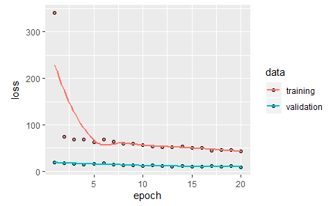

```r
plot(ann_history)
```

```r
predictions=model %>% predict(as.matrix(test_data))
rmse= function(x,y){
return((mean((x - y)^2))^0.5)
}
rmse(predictions,test_labels)
```

```
[1] 3.007163
```

#### Compare RMSE between models

At the end, we will compare RMSEs between Lasso, Ridge, Elastic Net, Raandom Forest, Gradient Boosted Tree and the RMSE of Neural Network above.

```r
compare=resamples(list(L=lasso,R=ridge,E=enet,F=m_rf,G=gbm))
summary(compare)
```

```
Call:
summary.resamples(object = compare)

Models: L, R, E, F, G
Number of resamples: 10

MAE
      Min.  1st Qu.   Median     Mean  3rd Qu.     Max. NA's
L 2.757495 2.811976 2.933891 2.900538 2.979525 3.017201    0
R 2.815781 2.915662 2.988813 2.988577 3.062781 3.137624    0
E 2.757495 2.811976 2.933891 2.900538 2.979525 3.017201    0
F 1.032856 1.086895 1.114968 1.124680 1.136884 1.305399    0
G 1.608131 1.646268 1.677918 1.696132 1.767724 1.788069    0

RMSE
      Min.  1st Qu.   Median     Mean  3rd Qu.     Max. NA's
L 3.642469 3.763792 3.882479 3.880624 4.009534 4.097495    0
R 3.714032 3.882282 4.033268 3.988035 4.071315 4.174545    0
E 3.642469 3.763792 3.882479 3.880624 4.009534 4.097495    0
F 1.582939 1.683107 1.745786 1.766198 1.830151 2.087196    0
G 2.173467 2.264114 2.313964 2.349434 2.413056 2.559439    0

Rsquared
       Min.   1st Qu.    Median      Mean   3rd Qu.      Max. NA's
L 0.8193328 0.8250857 0.8328609 0.8351465 0.8472730 0.8493639    0
R 0.8110106 0.8162529 0.8260314 0.8259341 0.8327557 0.8429036    0
E 0.8193328 0.8250857 0.8328609 0.8351465 0.8472730 0.8493639    0
F 0.9523128 0.9646284 0.9669882 0.9660532 0.9681419 0.9747209    0
G 0.9281065 0.9373270 0.9414176 0.9395371 0.9427526 0.9468698    0
```

## Results

As the results of RSMEs, we could see that errors of the machine learning models are low. This meant that the machine learning models performed good in predicting the life expectancy. Random Forest seemed to be the best model since its rmse is lowest compared to others models.